# MPDW Pertemuan 5

Wildy Fahmi Rosyidi G1401231066

2025-10-01

```r
library(ggplot2)
library(tsibble)
library(tseries)
library(MASS)
library(rio)
```

## Input Data

```r
data_mpdw <- import("https://raw.githubusercontent.com/nyayunabila/mpdw/refs/heads/main/data%20kelompok%209%20-%20Sheet1.csv")
head(data_mpdw)
```

```
##         date daily_revenue
## 1 19/08/2023        334,32
## 2 20/08/2023        140,92
## 3 21/08/2023        296,88
## 4 22/08/2023        157,86
## 5 23/08/2023        211,18
## 6 24/08/2023         76,58
```

```r
data_301to400 <- data_mpdw[301:400, ]
data_301to400
```

```
##           date daily_revenue
## 301 14/06/2024        312,55
## 302 15/06/2024        151,53
## 303 16/06/2024        246,88
## 304 17/06/2024        234,16
## 305 18/06/2024         219,8
## 306 19/06/2024        217,96
## 307 20/06/2024        159,64
## 308 21/06/2024        210,33
## 309 22/06/2024         118,2
## 310 23/06/2024         271,7
## 311 24/06/2024        328,04
## 312 25/06/2024        337,63
## 313 26/06/2024         279,3
## 314 27/06/2024        294,11
```

[output cut: 86 more lines]

## Plot Time Series

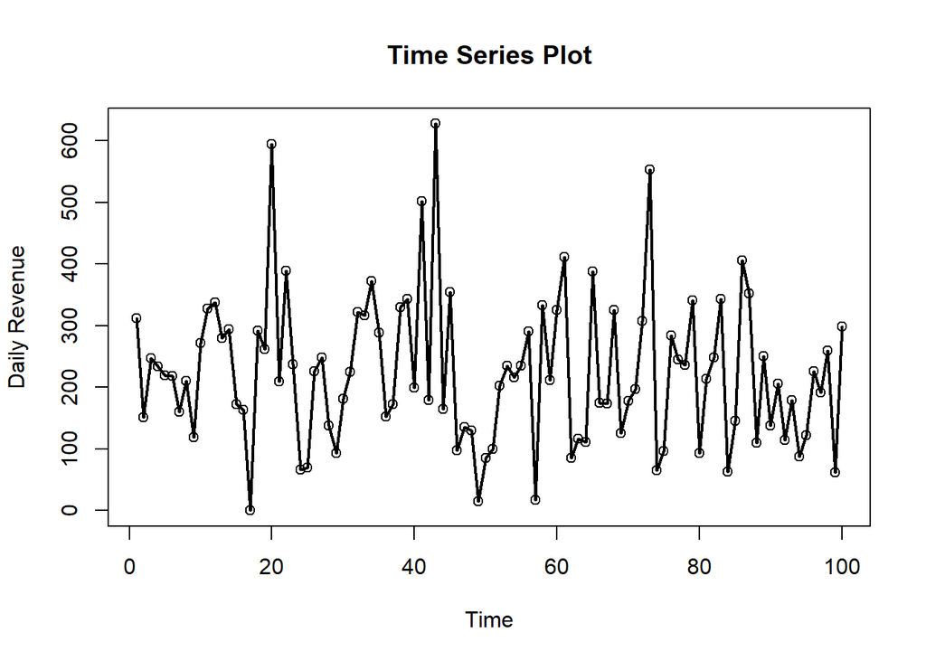

```r
data_301to400$daily_revenue <- gsub(",", ".", data_301to400$daily_revenue)

data_301to400$daily_revenue <- as.numeric(data_301to400$daily_revenue)

data_pertemuan5 <- ts(data_301to400$daily_revenue)

ts.plot(data_pertemuan5,
        xlab="Time",
        ylab="Daily Revenue",
        main="Time Series Plot",
        lwd=2)
points(data_pertemuan5)
```

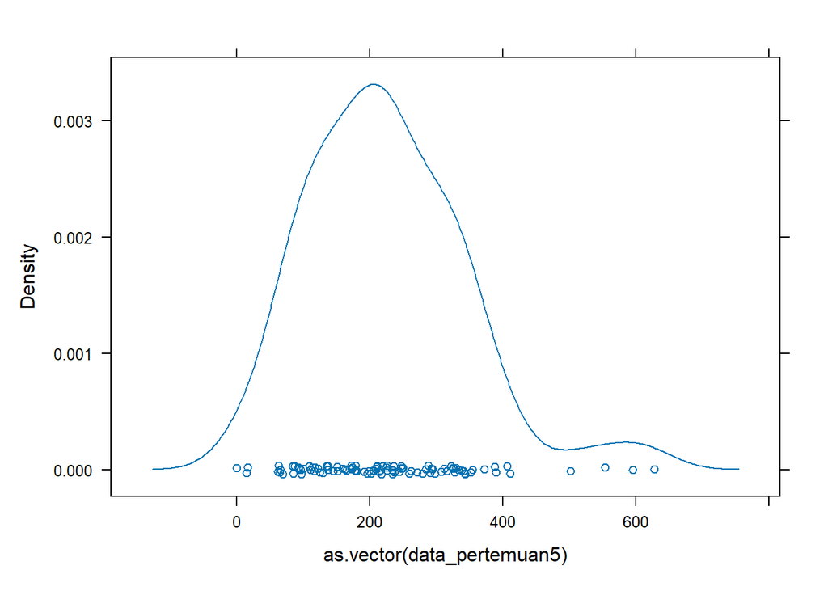

```r
lattice::densityplot(as.vector(data_pertemuan5))
```

Dari grafik diatas terlihat masih terdapat beberapa pencilan pada data.

## Uji Stasioner Dalam Rataan dan Ragam

### ACF

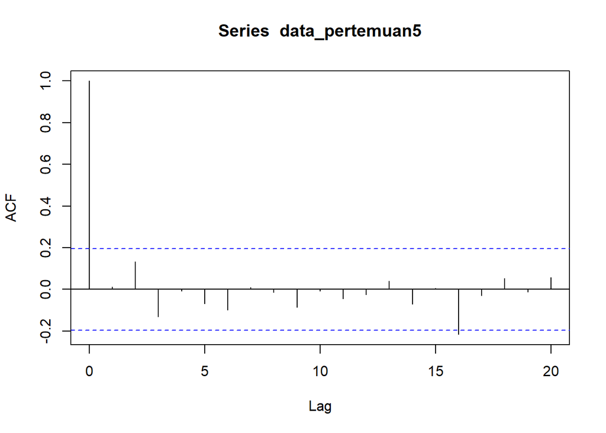

```r
acf(data_pertemuan5)
```

### Uji ADF

```r
tseries::adf.test(data_pertemuan5)
```

```
##
##  Augmented Dickey-Fuller Test
##
## data:  data_pertemuan5
## Dickey-Fuller = -4.6444, Lag order = 4, p-value = 0.01
## alternative hypothesis: stationary
```

Karena p-value < 0,05 menandakan bahwa data sudah stasioner dalam rataan.

### Plot Box-Cox

Bila ingin membuat plot box-cox pastikan variabel y nya tidak ada yang 0. Maka akan dicek apakah ada variabel y yang bernilai 0.

```r
any(data_301to400$daily_revenue == 0)
```

```
## [1] TRUE
```

Ternyata ada data yang bernilai 0. Agar data tidak ada yang berniali 0 maka akan dijumlahkan dengan 1.

```r
data_pertemuan5_geser <- data_pertemuan5 + 1
```

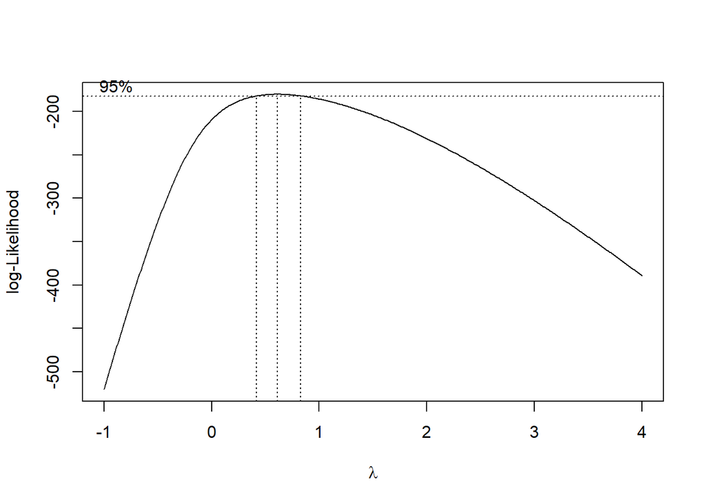

```r
index <- seq(1:100)
bc = boxcox(data_pertemuan5_geser ~ index, lambda = seq(-1,4,by=0.01))
```

```r
lambda <- bc$x[which.max(bc$y)]
lambda
```

```
## [1] 0.61
```

```r
bc$x[bc$y > max(bc$y) - 1/2 * qchisq(.95,1)]
```

```
##  [1] 0.42 0.43 0.44 0.45 0.46 0.47 0.48 0.49 0.50 0.51 0.52 0.53 0.54 0.55 0.56
## [16] 0.57 0.58 0.59 0.60 0.61 0.62 0.63 0.64 0.65 0.66 0.67 0.68 0.69 0.70 0.71
## [31] 0.72 0.73 0.74 0.75 0.76 0.77 0.78 0.79 0.80 0.81 0.82
```

Dari hasil plot diatas, dalam rentang tidak termasuk nilai lambda = 1. Berarti data tidak stasioner dalam ragam. Dan didapatkan nilai lambda optimum nya `0.61`dengan batas bawahnya `0.42` dan batas atasnya `0.82`

### Transformasi Box-cox

Karena lambda optimum nya mendekati nilai `0,5` maka akan dilakukan transformasi akar terhadap daily revenue

```r
data_boxcox <- data_pertemuan5_geser^0.5
```

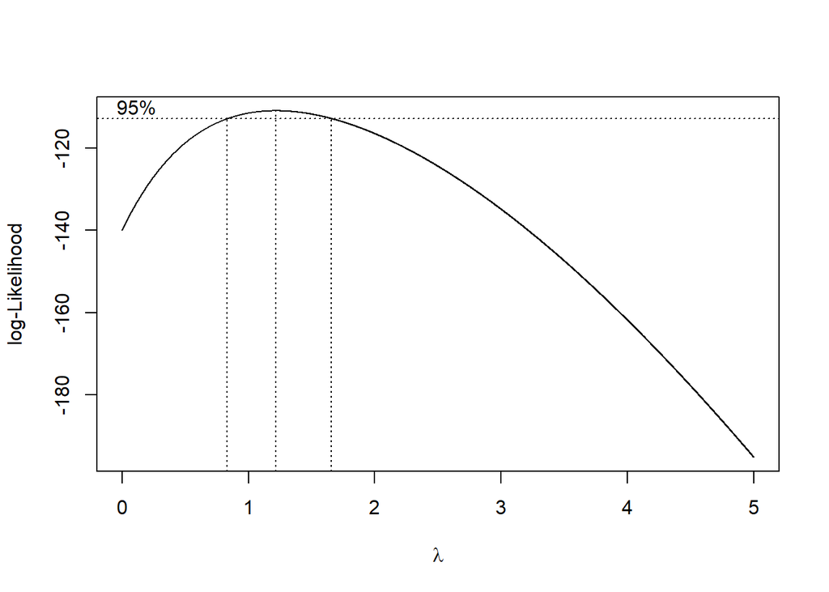

```r
index <- seq(1:100)

bc2 <- boxcox(
  data_boxcox ~ index,
  lambda = seq(0, 5, by = 0.001)
)
```

```r
lambda <- bc2$x[which.max(bc2$y)]
lambda
```

```
## [1] 1.217
```

```r
ci_lambda <- bc2$x[bc2$y > max(bc2$y) - 0.5 * qchisq(0.95, 1)]

ci_lower <- min(ci_lambda)
ci_upper <- max(ci_lambda)

c(Batas_Bawah = ci_lower, Batas_Atas = ci_upper)
```

```
## Batas_Bawah  Batas_Atas
##       0.833       1.657
```

Setelah dilakukan transformasi box-cox terlihat bahwa data sudah stasioner dalam ragam.

### Pengecekan Ulang

Untuk memastikan, akan dilakukan pengujian ulang kestasioneran dalam rataan terhadap model yang sudah transformasi

#### ACF

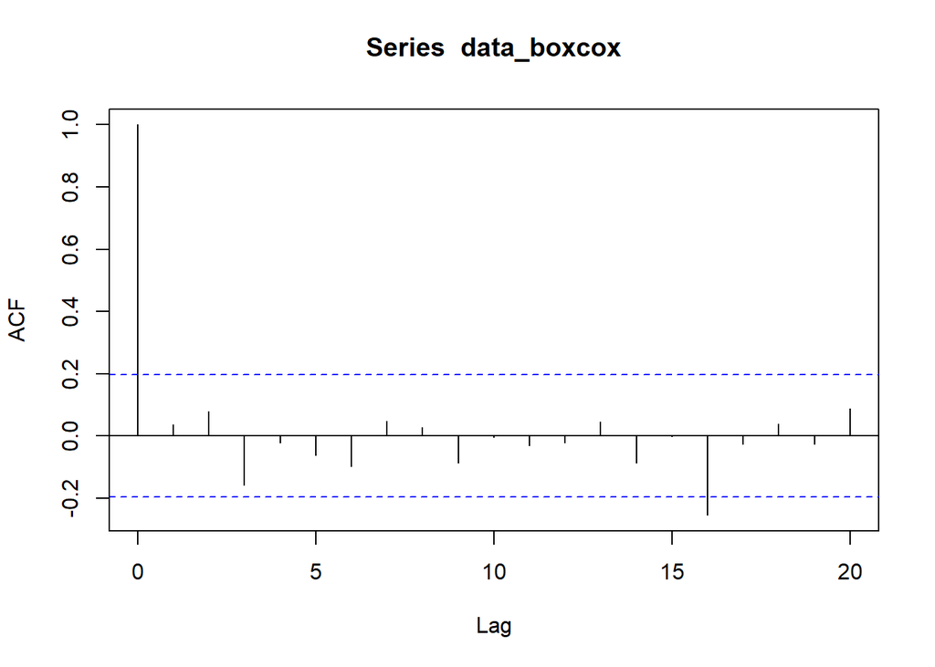

```r
acf(data_boxcox)
```

#### Uji ADF

```r
tseries::adf.test(data_boxcox)
```

```
##
##  Augmented Dickey-Fuller Test
##
## data:  data_boxcox
## Dickey-Fuller = -4.777, Lag order = 4, p-value = 0.01
## alternative hypothesis: stationary
```

Karena p-value < 0.05. Maka data setelah transformasi sudah stasioner dalam rataan dan juga dalam ragam.